# Tutorial: Contrast Analysis with Equivalence Testing

A Beginner-Friendly Guide to `contrast_analysis()`

# 1 What Does This Function Do?

In experimental psychology, we often predict a specific *pattern* of means across conditions. For example, we might predict that aggression increases linearly across three exposure conditions: Control < Low < High.

A standard omnibus ANOVA tells us *whether the means differ*, but not *whether they differ in the way we predicted*. Contrast analysis solves this by decomposing the between-group variance into two parts:

1. **The contrast of interest** — the part of the variance that follows your predicted pattern.
2. **The residual contrasts** — everything left over (i.e., deviations from your predicted pattern).

The `contrast_analysis()` function tests both pieces:

- It runs **NHST** on the contrast of interest (is the predicted trend significant?).
- It runs **TOST equivalence tests** on each residual contrast (are the deviations from the predicted pattern negligibly small?).

The logic follows the **Intersection-Union Test (IUT)** principle (Berger, 1982): because the tests are on orthogonal contrasts, no alpha correction is needed across them.

## 1.1 Why This Function? The Problem with Traditional Residual Testing

The traditional “Contrast + Residual” (C+R) approach tests both the contrast of interest and the residual contrasts using NHST. The reasoning goes: if the contrast of interest is significant and the residuals are not significant, the predicted pattern is confirmed.

The problem is that **a non-significant residual does not mean the residual is zero**. This is a textbook logical error: absence of evidence is not evidence of absence (Altman & Bland, 1995; Hartung et al., 1983). A non-significant *p*-value for a residual contrast could mean the deviation truly is negligible, but it could also mean the study simply lacked statistical power to detect it.

Richter (2016) formalized this critique, showing that when samples are small or residual effects are modest, traditional NHST-based residual tests have dangerously low power. In practice, this means researchers routinely “confirm” their predicted patterns by failing to reject a null they were never powered to detect — a problem that grows worse with more conditions (and thus more residual contrasts).

Faced with this issue, many researchers have essentially given up on testing residuals and instead only report the contrast of interest, treating residuals as a nuisance. This is understandable but unsatisfying: it means the analysis can tell you that the predicted trend *exists*, but it cannot tell you whether the predicted pattern *fully accounts* for the between-condition differences. An alternative pattern — one not predicted by your theory — could be driving much of the variance, and you would never know.

This function offers a principled middle ground. Instead of relying on non-significance (which proves nothing), it uses **equivalence testing** (TOST; Lakens, 2017) to affirmatively demonstrate that residual deviations are *negligibly small* — smaller than a threshold you pre-specify. This shifts the burden of proof: rather than hoping the residuals “aren’t significant,” you now provide positive statistical evidence that they fall within bounds you consider trivial. Following Campbell (2024), the equivalence test is applied to standardized regression coefficients from the contrast model.

The result is a framework that lets you both (1) establish that the predicted effect exists and (2) rule out meaningful alternative patterns — the full Contrast + Residual logic, done correctly.

## 1.2 The Three Possible Conclusions

| Conclusion | Meaning |
| --- | --- |
| **SUPPORTED** | The predicted trend is significant AND all residual deviations are equivalent to zero. |
| **PARTIALLY SUPPORTED** | The predicted trend is significant, BUT at least one residual is not equivalent to zero. |
| **NOT SUPPORTED** | The predicted trend is not significant. |

## 1.3 Key References

- **Campbell (2024)** — equivalence testing for linear regression.
- **Richter (2016)** — critique of NHST-based residual tests.
- **Berger (1982)** — Intersection-Union Test (IUT).
- **Lakens (2017)** — TOST equivalence testing.

# 2 Setup

```r
library(contrastanalysis)

# We use MASS for data generation in this tutorial
library(MASS)
library(ggplot2)
```

# 3 Your First Analysis: Between-Subjects

## 3.1 Create Some Data

Imagine an experiment with four conditions — A, B, C, D — where we predict a linear dose–response: the dependent variable increases equally from A to D.

```r
set.seed(42)

# 60 participants per group, true means = 2, 4, 6, 8, SD = 3
n_per <- 60
data_between <- data.frame(
  group = rep(c("A", "B", "C", "D"), each = n_per),
  score = c(
    rnorm(n_per, mean = 2, sd = 3),
    rnorm(n_per, mean = 4, sd = 3),
    rnorm(n_per, mean = 6, sd = 3),
    rnorm(n_per, mean = 8, sd = 3)
  )
)
```

## 3.2 Run the Analysis

There are five arguments you always need to specify:

| Argument | What it is |
| --- | --- |
| `data` | Your data frame. |
| `dv` | The name of your dependent variable column (as a string). |
| `conditions` | The name of your grouping variable column (as a string). |
| `hypothesis` | A **named numeric vector** specifying your predicted pattern. |
| `delta` | The equivalence bound (how small is “negligible”?). |

The `hypothesis` vector is the heart of the function. The **names** must match the levels of your grouping variable, and the **values** encode the predicted relative ordering. For a linear pattern across A, B, C, D:

```r
result <- contrast_analysis(
  data       = data_between,
  dv         = "score",
  conditions = "group",
  hypothesis = c(A = 0, B = 1, C = 2, D = 3),
  delta      = 0.3
)
```

```
##
## =================================================================
##       CONTRAST ANALYSIS WITH EQUIVALENCE TESTING
## =================================================================
##
## Design:  between-subjects
## Groups:  A, B, C, D (k = 4)
## N:       240
## Alpha:   0.05
## Orthogonal contrasts: Yes
## Effect size metric: d = b / sigma (b = contrast coefficient, sigma = sqrt(MSE))
##
## Hypothesized pattern: A < B < C < D
##
## ----- Contrast Weights -----
##                 InterestResidual 1Residual 2
##   A              -0.6708   -0.4236   -0.3472
##   B              -0.2236    0.3060    0.7787
##   C               0.2236    0.6588   -0.5157
##   D               0.6708   -0.5412    0.0843
##
##   Note: Residual contrasts are one possible orthonormal basis for the
##   subspace orthogonal to the predicted pattern. Individual residual
##   vectors are not uniquely defined, but their joint test is invariant:
##   if any systematic deviation from the predicted pattern exists, at
##   least one residual will detect it.
##
## ----- Contrast of Interest (NHST) -----
##   b = 4.225, SE = 0.375, t(236) = 11.254, p < .001 [SIGNIFICANT]
##   d = 1.453, 95% CI [1.198, 1.707]
##
## ----- Residual Contrasts (TOST Equivalence Tests) -----
##   Equivalence bounds (standardized): +/-0.300, +/-0.300
##
##   Residual 1:
##     Weights: A: -0.424, B: +0.306, C: +0.659, D: -0.541
##     NHST: b = -0.043, SE = 0.375, t(236) = -0.113, p = 0.910
##     TOST: d = -0.015, 90% CI [-0.228, 0.199]
##           p1 = 0.014, p2 = 0.008, p_TOST = 0.014 [EQUIVALENT (within bounds)]
##
```

[output cut: 9 more lines]

```
##   Residual 2:           1.0%
##
## =================================================================
##   CONCLUSION: PARTIALLY SUPPORTED
## =================================================================
##   The data partially support the hypothesized pattern. The
##   contrast of interest is statistically significant, but not all
##   residual contrasts could be declared equivalent to zero. The
##   hypothesized pattern does not fully account for the
##   between-condition differences.
##
## ----- APA-Formatted Results -----
## Contrast of interest: b = 4.23, SE = 0.38, t(236) = 11.25, p < .001, d = 1.45, 95% CI [1.20, 1.71].
## Residual contrast 1 (TOST): b = -0.04, SE = 0.38, d = -0.01, 90% CI [-0.23, 0.20], equivalence bounds = +/-0.30, t1(236) = 2.21, p1 = .014, t2(236) = -2.44, p2 = .008, p_TOST = .014 (equivalent to zero).
## Residual contrast 2 (TOST): b = 0.43, SE = 0.38, d = 0.15, 90% CI [-0.07, 0.36], equivalence bounds = +/-0.30, t1(236) = 3.46, p1 < .001, t2(236) = -1.19, p2 = .118, p_TOST = .118 (not equivalent to zero).
```

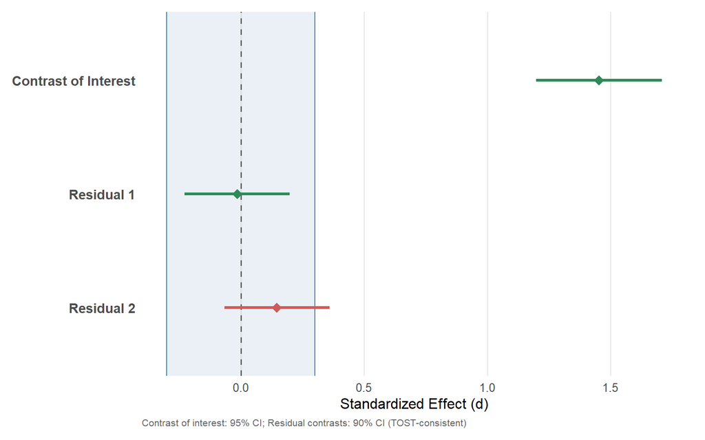

## 3.3 Reading the Output

The output is printed automatically. Let’s walk through each section.

### 3.3.1 Contrast of Interest (NHST)

This tests whether the linear trend you predicted is statistically significant. You’ll see a regression coefficient (`b`), its standard error, a *t*-test, and a standardized effect size (`d = b / sigma`, where sigma is the square root of MSE).

If this is significant, your predicted pattern is present in the data.

### 3.3.2 Residual Contrasts (TOST Equivalence Tests)

For *k* = 4 groups there are *k* − 1 = 3 total degrees of freedom among means. One is used by your contrast of interest, leaving *k* − 2 = 2 residual contrasts. These capture *everything your predicted pattern does not explain*.

Each residual is tested with a **Two One-Sided Tests (TOST)** procedure. TOST asks: “Is this effect small enough to be considered equivalent to zero?” You’ll see:

- The standardized effect (`d`) and its **90% CI** (TOST-consistent).
- Two one-sided *p*-values (`p1`, `p2`) and their maximum (`p_TOST`).
- A verdict: **EQUIVALENT** or **NOT equivalent**.

If p_TOST < alpha, the residual is declared equivalent to zero.

### 3.3.3 Variance Decomposition

This shows what percentage of the model (between-group) variance is captured by your predicted pattern versus the residuals. Ideally, the contrast of interest accounts for nearly all of it (e.g., 95%+).

# 4 The `hypothesis` Argument in Detail

The `hypothesis` argument is the heart of the function. It tells the function *what pattern you predict*. Let’s walk through exactly how this works.

## 4.1 What the Values Mean

You supply a named numeric vector where:

- The **names** are your condition/group labels (must match the factor levels in your data).
- The **values** encode the predicted *relative* pattern of means.

Only the **relative spacing** matters. The function centers the values (subtracts their mean) and normalizes them to unit length internally. So all of these specify the exact same linear contrast:

```r
# These are all identical:
hypothesis = c(A = 0, B = 1, C = 2, D = 3)
hypothesis = c(A = 0, B = 0.5, C = 1, D = 1.5)
hypothesis = c(A = 10, B = 20, C = 30, D = 40)
```

Think of the values as “predicted mean scores on an arbitrary scale.” If you predict that A has the lowest score, B is a little higher, C higher still, and D the highest — with equal steps between them — then `c(A = 0, B = 1, C = 2, D = 3)` encodes this perfectly.

## 4.2 How the Function Builds the Contrasts

From your hypothesis values, the function automatically constructs a full set of **orthogonal contrasts** that partition the *k* − 1 degrees of freedom among group means:

1. **Contrast of interest (1 df):** Derived directly from your hypothesis. The centered and normalized values become the contrast weights. This tests: “Do the group means follow the predicted pattern?”
2. **Residual contrasts (*k* − 2 df):** The function uses `MASS::Null()` to compute an orthonormal basis for the subspace orthogonal to both the intercept and the contrast of interest. These residuals collectively capture *everything your predicted pattern does not explain*.

The output displays the full contrast weights table so you can see exactly what is being tested.

## 4.3 A Note on Residual Contrasts

An important subtlety: the individual residual contrast vectors are **not uniquely defined**. `MASS::Null()` returns one possible basis, but any rotation within the residual subspace would be equally valid. This means the label “Residual 1” vs. “Residual 2” is arbitrary — you should not over-interpret which specific comparison each residual corresponds to.

What *is* invariant is their **joint** behavior: the set of residual contrasts as a whole captures all systematic deviations from your predicted pattern. If any such deviation exists, at least one residual will pick it up. This is why the function tests each residual and requires *all* of them to be equivalent to zero for a “SUPPORTED” conclusion.

## 4.4 Non-Linear Spacing

The values don’t have to be evenly spaced. You can encode any monotonic (or non-monotonic) pattern you predict:

```r
# Diminishing returns: big jump from A to B, smaller increments after
hypothesis = c(A = 0, B = 3, C = 4, D = 4.5)

# Dose-response matching actual doses (0, 1, 3, 5 mg)
hypothesis = c(Placebo = 0, Low = 1, Med = 3, High = 5)

# Quadratic (inverted U): peak at B/C, lower at extremes
hypothesis = c(A = 0, B = 1, C = 1, D = 0)
```

The spacing directly determines the contrast weights, so `c(0, 1, 3, 5)` tests a different pattern than `c(0, 1, 2, 3)`. The first gives more weight to the jump from Low to Med (which spans 2 units) than from Placebo to Low (which spans 1 unit).

## 4.5 Encoding Equality Constraints (Ties)

You can predict that some conditions are **equal** by giving them the same value. For example, to test “[A = B] < [C = D]”:

```r
set.seed(99)
data_tie <- data.frame(
  group = rep(c("A","B","C","D"), each = 50),
  score = c(rnorm(50, 3, 2), rnorm(50, 3, 2),
            rnorm(50, 7, 2), rnorm(50, 7, 2))
)

result_tie <- contrast_analysis(
  data       = data_tie,
  dv         = "score",
  conditions = "group",
  hypothesis = c(A = 0, B = 0, C = 1, D = 1),
  delta      = 0.3,
  graph1     = FALSE
)
```

```
##
## =================================================================
##       CONTRAST ANALYSIS WITH EQUIVALENCE TESTING
## =================================================================
##
## Design:  between-subjects
## Groups:  A, B, C, D (k = 4)
## N:       200
## Alpha:   0.05
## Orthogonal contrasts: Yes
## Effect size metric: d = b / sigma (b = contrast coefficient, sigma = sqrt(MSE))
##
## Hypothesized pattern: [A = B] < [C = D]
##
## ----- Contrast Weights -----
##                 InterestResidual 1Residual 2
##   A              -0.5000   -0.5000   -0.5000
##   B              -0.5000    0.5000    0.5000
##   C               0.5000    0.5000   -0.5000
##   D               0.5000   -0.5000    0.5000
##
##   Note: Residual contrasts are one possible orthonormal basis for the
##   subspace orthogonal to the predicted pattern. Individual residual
##   vectors are not uniquely defined, but their joint test is invariant:
##   if any systematic deviation from the predicted pattern exists, at
##   least one residual will detect it.
##
## ----- Contrast of Interest (NHST) -----
##   b = 4.033, SE = 0.279, t(196) = 14.457, p < .001 [SIGNIFICANT]
##   d = 2.045, 95% CI [1.766, 2.323]
##
## ----- Residual Contrasts (TOST Equivalence Tests) -----
##   Equivalence bounds (standardized): +/-0.300, +/-0.300
##
##   Residual 1:
##     Weights: A: -0.500, B: +0.500, C: +0.500, D: -0.500
##     NHST: b = 0.268, SE = 0.279, t(196) = 0.963, p = 0.337
##     TOST: d = 0.136, 90% CI [-0.098, 0.370]
##           p1 = 0.001, p2 = 0.124, p_TOST = 0.124 [NOT equivalent]
##
```

[output cut: 9 more lines]

```
##   Residual 2:           0.6%
##
## =================================================================
##   CONCLUSION: PARTIALLY SUPPORTED
## =================================================================
##   The data partially support the hypothesized pattern. The
##   contrast of interest is statistically significant, but not all
##   residual contrasts could be declared equivalent to zero. The
##   hypothesized pattern does not fully account for the
##   between-condition differences.
##
## ----- APA-Formatted Results -----
## Contrast of interest: b = 4.03, SE = 0.28, t(196) = 14.46, p < .001, d = 2.04, 95% CI [1.77, 2.32].
## Residual contrast 1 (TOST): b = 0.27, SE = 0.28, d = 0.14, 90% CI [-0.10, 0.37], equivalence bounds = +/-0.30, t1(196) = 3.08, p1 = .001, t2(196) = -1.16, p2 = .124, p_TOST = .124 (not equivalent to zero).
## Residual contrast 2 (TOST): b = 0.33, SE = 0.28, d = 0.16, 90% CI [-0.07, 0.40], equivalence bounds = +/-0.30, t1(196) = 3.29, p1 < .001, t2(196) = -0.96, p2 = .170, p_TOST = .170 (not equivalent to zero).
```

The output’s “Hypothesized pattern” line will display: `[A = B] < [C = D]`.

## 4.6 More Examples of Hypothesis Encoding

Here are several common experimental designs and how to encode them:

```r
# 1. Simple two-level comparison with a third reference group
#    "Treatment is better than both controls, which are equal"
hypothesis = c(Control1 = 0, Control2 = 0, Treatment = 1)

# 2. Helmert-style: "Any intervention > no intervention"
#    Three interventions vs. one control
hypothesis = c(Relevance = 1, PeerModel = 1, GrowthMindset = 1, Control = 0)

# 3. Linear trend across five time points
hypothesis = c(T1 = 1, T2 = 2, T3 = 3, T4 = 4, T5 = 5)

# 4. Step function: "Nothing happens until the threshold, then it jumps"
hypothesis = c(Dose0 = 0, Dose1 = 0, Dose2 = 1, Dose3 = 1)

# 5. Three ordered groups with predicted unequal spacing
#    "Experts >> Intermediates > Novices"
hypothesis = c(Novice = 0, Intermediate = 1, Expert = 3)
```

# 5 Within-Subjects Designs

The function also handles repeated-measures data. The key differences:

- Data must be in **wide format** (one row per participant, one column per condition).
- Set `design = "within"`.
- Set `dv = NULL` and `conditions = NULL`.
- Provide the participant ID column with `id`.

```r
set.seed(77)

n <- 50
Sigma <- matrix(c(9, 4.5, 4.5,
                  4.5, 9, 4.5,
                  4.5, 4.5, 9), nrow = 3)
scores <- MASS::mvrnorm(n, mu = c(5, 8, 8), Sigma = Sigma)

data_within <- data.frame(
  pid   = 1:n,
  Ctrl  = scores[, 1],
  DrugA = scores[, 2],
  DrugB = scores[, 3]
)
```

Here we predict that the control is lower than both drug conditions, which are equal to each other:

```r
result_within <- contrast_analysis(
  data       = data_within,
  dv         = NULL,
  conditions = NULL,
  hypothesis = c(Ctrl = 0, DrugA = 1, DrugB = 1),
  design     = "within",
  id         = "pid",
  delta      = 0.3
)
```

```
##
## =================================================================
##       CONTRAST ANALYSIS WITH EQUIVALENCE TESTING
## =================================================================
##
## Design:  within-subjects
## Groups:  Ctrl, DrugA, DrugB (k = 3)
## N:       50
## Alpha:   0.05
## Orthogonal contrasts: Yes
## Effect size metric: d_z = M / SD (M and SD of within-subject contrast scores)
##
## Hypothesized pattern: Ctrl < [DrugA = DrugB]
##
## ----- Contrast Weights -----
##                 InterestResidual 1
##   Ctrl           -0.8165    0.0000
##   DrugA           0.4082   -0.7071
##   DrugB           0.4082    0.7071
##
##   Note: Residual contrasts are one possible orthonormal basis for the
##   subspace orthogonal to the predicted pattern. Individual residual
##   vectors are not uniquely defined, but their joint test is invariant:
##   if any systematic deviation from the predicted pattern exists, at
##   least one residual will detect it.
##
## ----- Contrast of Interest (NHST) -----
##   b = 2.695, SE = 0.331, t(49) = 8.145, p < .001 [SIGNIFICANT]
##   d = 1.152, 95% CI [0.785, 1.518]
##
## ----- Residual Contrasts (TOST Equivalence Tests) -----
##   Equivalence bounds (standardized): +/-0.300
##
##   Residual 1:
##     Weights: Ctrl: +0.000, DrugA: -0.707, DrugB: +0.707
##     NHST: b = -0.092, SE = 0.324, t(49) = -0.284, p = 0.777
##     TOST: d = -0.040, 90% CI [-0.277, 0.197]
##           p1 = 0.036, p2 = 0.010, p_TOST = 0.036 [EQUIVALENT (within bounds)]
##
## ----- Variance Decomposition -----
##   Contrast of Interest: 99.9%
##   Residual 1:           0.1%
##
## =================================================================
##   CONCLUSION: SUPPORTED
## =================================================================
##   The data fully support the hypothesized pattern. The contrast
##   of interest is statistically significant, and all residual
##   contrasts are equivalent to zero (within the specified
##   equivalence bounds).
##
## ----- APA-Formatted Results -----
## Contrast of interest: b = 2.70, SE = 0.33, t(49) = 8.14, p < .001, d = 1.15, 95% CI [0.79, 1.52].
## Residual contrast 1 (TOST): b = -0.09, SE = 0.32, d = -0.04, 90% CI [-0.28, 0.20], equivalence bounds = +/-0.30, t1(49) = 1.84, p1 = .036, t2(49) = -2.41, p2 = .010, p_TOST = .036 (equivalent to zero).
```

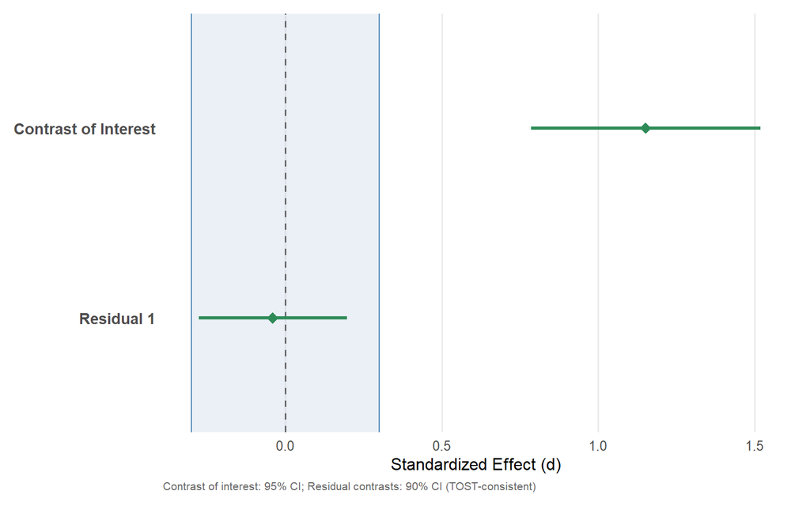

For within-subjects designs, the effect size is **d_z** (the mean of within-subject contrast scores divided by their standard deviation).

# 6 Understanding `delta`: The Equivalence Bound

The `delta` parameter is perhaps the most important decision you make. It defines “how small is small enough?” for the residual contrasts. If a residual’s standardized effect falls within ±delta, it’s declared equivalent to zero.

## 6.1 What Does Delta Mean?

Delta is expressed in **standardized units** (Cohen’s *d* scale):

- Between-subjects: *d* = *b* / sigma, where sigma = sqrt(MSE).
- Within-subjects: *d_z* = *M* / *SD* of contrast scores.

A delta of 0.3 means: “I consider a residual negligible if its standardized effect is smaller than 0.3 in absolute value.”

## 6.2 How to Choose Delta

There is no single correct value. Your choice should be justified on substantive grounds. Some approaches:

1. **Anchor to effect-size benchmarks.** If your field considers *d* = 0.20 a “small” effect, you might set delta = 0.20 (anything smaller than “small” is negligible).
2. **Anchor to the smallest effect size of interest (SESOI).** If your theory says an effect below *d* = 0.15 is theoretically meaningless, set delta = 0.15.
3. **Anchor to practical significance.** What is the smallest deviation from your predicted pattern that would change your theoretical conclusions?

Tighter bounds (smaller delta) are more conservative — they require stronger evidence that the residuals are truly small. But they also require larger sample sizes.

## 6.3 Specifying Different Deltas for Each Residual

For *k* groups there are *k* − 2 residual contrasts. You can set a single delta (applied to all) or a vector of deltas (one per residual):

```r
# Same bound for all residuals
result_same <- contrast_analysis(
  data_between, "score", "group",
  hypothesis = c(A = 0, B = 1, C = 2, D = 3),
  delta      = 0.3,
  graph1     = FALSE
)
```

```
##
## =================================================================
##       CONTRAST ANALYSIS WITH EQUIVALENCE TESTING
## =================================================================
##
## Design:  between-subjects
## Groups:  A, B, C, D (k = 4)
## N:       240
## Alpha:   0.05
## Orthogonal contrasts: Yes
## Effect size metric: d = b / sigma (b = contrast coefficient, sigma = sqrt(MSE))
##
## Hypothesized pattern: A < B < C < D
##
## ----- Contrast Weights -----
##                 InterestResidual 1Residual 2
##   A              -0.6708   -0.4236   -0.3472
##   B              -0.2236    0.3060    0.7787
##   C               0.2236    0.6588   -0.5157
##   D               0.6708   -0.5412    0.0843
##
##   Note: Residual contrasts are one possible orthonormal basis for the
##   subspace orthogonal to the predicted pattern. Individual residual
##   vectors are not uniquely defined, but their joint test is invariant:
##   if any systematic deviation from the predicted pattern exists, at
##   least one residual will detect it.
##
## ----- Contrast of Interest (NHST) -----
##   b = 4.225, SE = 0.375, t(236) = 11.254, p < .001 [SIGNIFICANT]
##   d = 1.453, 95% CI [1.198, 1.707]
##
## ----- Residual Contrasts (TOST Equivalence Tests) -----
##   Equivalence bounds (standardized): +/-0.300, +/-0.300
##
##   Residual 1:
##     Weights: A: -0.424, B: +0.306, C: +0.659, D: -0.541
##     NHST: b = -0.043, SE = 0.375, t(236) = -0.113, p = 0.910
##     TOST: d = -0.015, 90% CI [-0.228, 0.199]
##           p1 = 0.014, p2 = 0.008, p_TOST = 0.014 [EQUIVALENT (within bounds)]
##
```

[output cut: 9 more lines]

```
##   Residual 2:           1.0%
##
## =================================================================
##   CONCLUSION: PARTIALLY SUPPORTED
## =================================================================
##   The data partially support the hypothesized pattern. The
##   contrast of interest is statistically significant, but not all
##   residual contrasts could be declared equivalent to zero. The
##   hypothesized pattern does not fully account for the
##   between-condition differences.
##
## ----- APA-Formatted Results -----
## Contrast of interest: b = 4.23, SE = 0.38, t(236) = 11.25, p < .001, d = 1.45, 95% CI [1.20, 1.71].
## Residual contrast 1 (TOST): b = -0.04, SE = 0.38, d = -0.01, 90% CI [-0.23, 0.20], equivalence bounds = +/-0.30, t1(236) = 2.21, p1 = .014, t2(236) = -2.44, p2 = .008, p_TOST = .014 (equivalent to zero).
## Residual contrast 2 (TOST): b = 0.43, SE = 0.38, d = 0.15, 90% CI [-0.07, 0.36], equivalence bounds = +/-0.30, t1(236) = 3.46, p1 < .001, t2(236) = -1.19, p2 = .118, p_TOST = .118 (not equivalent to zero).
```

```r
# Different bounds: stricter for Residual 1, more lenient for Residual 2
result_diff <- contrast_analysis(
  data_between, "score", "group",
  hypothesis = c(A = 0, B = 1, C = 2, D = 3),
  delta      = c(0.15, 0.40),
  graph1     = FALSE
)
```

```
##
## =================================================================
##       CONTRAST ANALYSIS WITH EQUIVALENCE TESTING
## =================================================================
##
## Design:  between-subjects
## Groups:  A, B, C, D (k = 4)
## N:       240
## Alpha:   0.05
## Orthogonal contrasts: Yes
## Effect size metric: d = b / sigma (b = contrast coefficient, sigma = sqrt(MSE))
##
## Hypothesized pattern: A < B < C < D
##
## ----- Contrast Weights -----
##                 InterestResidual 1Residual 2
##   A              -0.6708   -0.4236   -0.3472
##   B              -0.2236    0.3060    0.7787
##   C               0.2236    0.6588   -0.5157
##   D               0.6708   -0.5412    0.0843
##
##   Note: Residual contrasts are one possible orthonormal basis for the
##   subspace orthogonal to the predicted pattern. Individual residual
##   vectors are not uniquely defined, but their joint test is invariant:
##   if any systematic deviation from the predicted pattern exists, at
##   least one residual will detect it.
##
## ----- Contrast of Interest (NHST) -----
##   b = 4.225, SE = 0.375, t(236) = 11.254, p < .001 [SIGNIFICANT]
##   d = 1.453, 95% CI [1.198, 1.707]
##
## ----- Residual Contrasts (TOST Equivalence Tests) -----
##   Equivalence bounds (standardized): +/-0.150, +/-0.400
##
##   Residual 1:
##     Weights: A: -0.424, B: +0.306, C: +0.659, D: -0.541
##     NHST: b = -0.043, SE = 0.375, t(236) = -0.113, p = 0.910
##     TOST: d = -0.015, 90% CI [-0.228, 0.199]
##           p1 = 0.148, p2 = 0.102, p_TOST = 0.148 [NOT equivalent]
##
```

[output cut: 9 more lines]

```
##   Residual 2:           1.0%
##
## =================================================================
##   CONCLUSION: PARTIALLY SUPPORTED
## =================================================================
##   The data partially support the hypothesized pattern. The
##   contrast of interest is statistically significant, but not all
##   residual contrasts could be declared equivalent to zero. The
##   hypothesized pattern does not fully account for the
##   between-condition differences.
##
## ----- APA-Formatted Results -----
## Contrast of interest: b = 4.23, SE = 0.38, t(236) = 11.25, p < .001, d = 1.45, 95% CI [1.20, 1.71].
## Residual contrast 1 (TOST): b = -0.04, SE = 0.38, d = -0.01, 90% CI [-0.23, 0.20], equivalence bounds = +/-0.15, t1(236) = 1.05, p1 = .148, t2(236) = -1.28, p2 = .102, p_TOST = .148 (not equivalent to zero).
## Residual contrast 2 (TOST): b = 0.43, SE = 0.38, d = 0.15, 90% CI [-0.07, 0.36], equivalence bounds = +/-0.40, t1(236) = 4.23, p1 < .001, t2(236) = -1.96, p2 = .025, p_TOST = .025 (equivalent to zero).
```

# 7 Equivalence Bounds from % of Model Variance (`delta_type = "share_signal"`)

Sometimes it’s more natural to think about equivalence in relative terms: “I want each residual to account for no more than X% of the model variance.” The `share_signal` feature lets you specify bounds this way.

## 7.1 The Idea

Your predicted pattern and the residuals together make up 100% of the model (between-group) variance. If your pattern is a good approximation, the residuals should account for only a tiny fraction of this total. Setting `delta_type = "share_signal"` lets you define “negligible” as a maximum tolerable percentage.

## 7.2 How It Works

The function converts your percentage into a *d*-scale bound using the formula:

$$\delta_d = d_{\text{interest, min}} \times \sqrt{\frac{p}{1 - p}}$$

where *p* is your maximum tolerable share (e.g., 0.05 for 5%) and *d*~interest, min~ is a reference effect size you supply for the contrast of interest. After this conversion, the existing TOST machinery runs on the converted *d* bound — nothing else changes.

## 7.3 The Two Required Inputs

| Argument | What it is |
| --- | --- |
| `delta` | The maximum tolerable % of model variance per residual (between 0 and 100). |
| `d_interest_min` | Your pre-specified SESOI for the contrast of interest, in standardized *d* units. |

You need `d_interest_min` because “5% of model variance” only translates into a concrete *d* bound if you know (or specify) how large the main effect is. This keeps the equivalence bounds **fixed and pre-specified**, which is essential for valid frequentist inference.

## 7.4 Example

Suppose you predict a linear dose–response, and you want each residual to account for no more than 5% of the model variance, assuming the contrast of interest is at least *d* = 0.80 (your SESOI for the main trend):

```
##
## =================================================================
##       CONTRAST ANALYSIS WITH EQUIVALENCE TESTING
## =================================================================
##
## Design:  between-subjects
## Groups:  A, B, C, D (k = 4)
## N:       240
## Alpha:   0.05
## Orthogonal contrasts: Yes
## Effect size metric: d = b / sigma (b = contrast coefficient, sigma = sqrt(MSE))
##
## Hypothesized pattern: A < B < C < D
##
## ----- Contrast Weights -----
##                 InterestResidual 1Residual 2
##   A              -0.6708   -0.4236   -0.3472
##   B              -0.2236    0.3060    0.7787
##   C               0.2236    0.6588   -0.5157
##   D               0.6708   -0.5412    0.0843
##
##   Note: Residual contrasts are one possible orthonormal basis for the
##   subspace orthogonal to the predicted pattern. Individual residual
##   vectors are not uniquely defined, but their joint test is invariant:
##   if any systematic deviation from the predicted pattern exists, at
##   least one residual will detect it.
##
## ----- Contrast of Interest (NHST) -----
##   b = 4.225, SE = 0.375, t(236) = 11.254, p < .001 [SIGNIFICANT]
##   d = 1.453, 95% CI [1.198, 1.707]
##
## ----- Residual Contrasts (TOST Equivalence Tests) -----
##   Delta type: share_signal (% of model variance)
##   Reference d_interest_min: 0.8
##   Equivalence bounds (converted to d-scale):
##     Residual 1: max share = 5.0% => d bound = +/-0.1835
##     Residual 2: max share = 5.0% => d bound = +/-0.1835
##
##   Residual 1:
##     Weights: A: -0.424, B: +0.306, C: +0.659, D: -0.541
```

[output cut: 23 more lines]

```
##   implicitly (interest must be significant for SUPPORTED).
##
## =================================================================
##   CONCLUSION: PARTIALLY SUPPORTED
## =================================================================
##   The data partially support the hypothesized pattern. The
##   contrast of interest is statistically significant, but not all
##   residual contrasts could be declared equivalent to zero. The
##   hypothesized pattern does not fully account for the
##   between-condition differences.
##
## ----- APA-Formatted Results -----
## Contrast of interest: b = 4.23, SE = 0.38, t(236) = 11.25, p < .001, d = 1.45, 95% CI [1.20, 1.71].
## Residual contrast 1 (TOST): b = -0.04, SE = 0.38, d = -0.01, 90% CI [-0.23, 0.20], equivalence bounds = +/-0.184 (from 5.0% share, d_int_min = 0.80), t1(236) = 1.31, p1 = .096, t2(236) = -1.53, p2 = .063, p_TOST = .096 (not equivalent to zero).
## Residual contrast 2 (TOST): b = 0.43, SE = 0.38, d = 0.15, 90% CI [-0.07, 0.36], equivalence bounds = +/-0.184 (from 5.0% share, d_int_min = 0.80), t1(236) = 2.56, p1 = .006, t2(236) = -0.29, p2 = .387, p_TOST = .387 (not equivalent to zero).
```

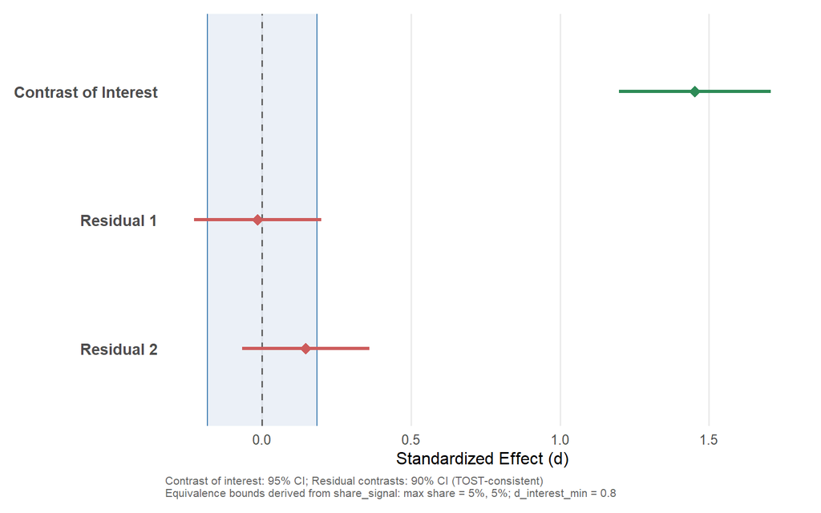

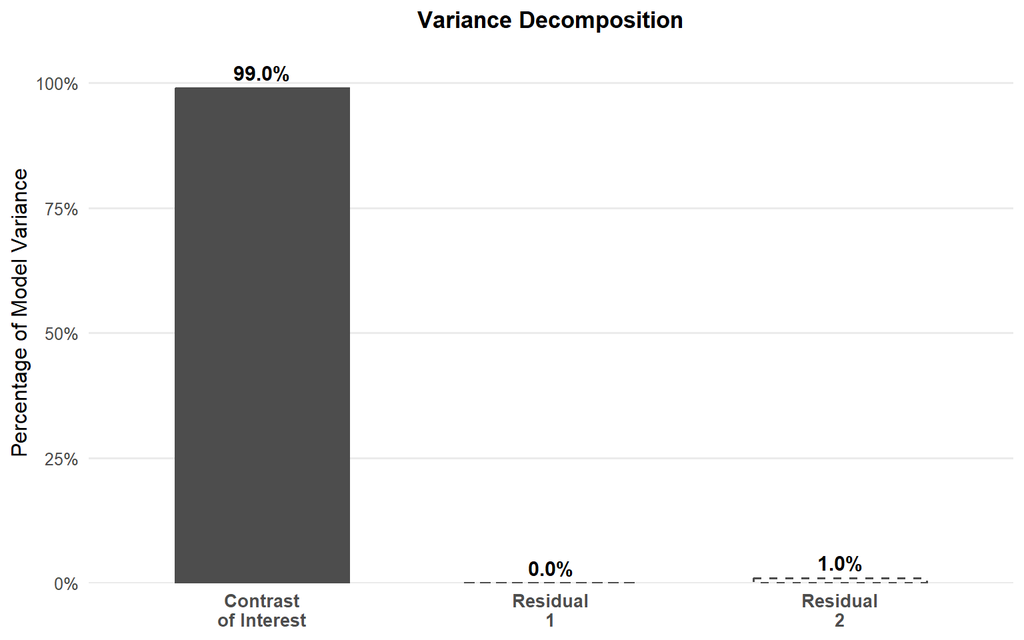

```r
result_share <- contrast_analysis(
  data       = data_between,
  dv         = "score",
  conditions = "group",
  hypothesis = c(A = 0, B = 1, C = 2, D = 3),
  delta      = 5,
  delta_type = "share_signal",
  d_interest_min = 0.80,
  graph1     = TRUE,
  graph2     = TRUE
)
```

Notice the additional sections in the output:

- **Equivalence bounds (converted to d-scale):** Shows the % you specified and the corresponding *d* bound.
- **Share-Based Equivalence Interpretation:** Documents the conversion formula and its assumptions.

## 7.5 Some Intuition for the Conversion

Here’s how different share thresholds translate to *d* bounds when *d*~interest, min~ = 1.0:

Table 7.1: Conversion from share to d bound (d_interest_min = 1.0)

| Max Share (%) | Converted d Bound |
| --- | --- |
| 1 | 0.1005 |
| 2 | 0.1429 |
| 5 | 0.2294 |
| 10 | 0.3333 |
| 20 | 0.5000 |
| 50 | 1.0000 |

Key observations:

- A 5% share corresponds to *d* ≈ 0.23 — quite stringent.
- A 50% share corresponds to *d* = 1.0 — very lenient (residuals as large as the interest effect would still pass).
- Smaller `d_interest_min` values produce proportionally tighter bounds.

## 7.6 When to Use `share_signal` vs. `dz`

| Use `dz` (the default) when… | Use `share_signal` when… |
| --- | --- |
| You have a substantive SESOI in *d* units for the residuals. | You think in terms of “% of variance explained.” |
| Your field has established benchmarks for “negligible” effects. | You have a clear SESOI for the main effect but not for residuals. |
| You want the simplest, most transparent specification. | You want bounds that are interpretable relative to the main signal. |

Both modes run the same underlying TOST. The only difference is how you *specify* the bound.

# 8 Graphs

The function produces two types of plots, both controlled by arguments.

## 8.1 Forest Plot (`graph1`)

The forest plot displays point estimates and confidence intervals for the contrast of interest and all residual contrasts on a single *d* axis:

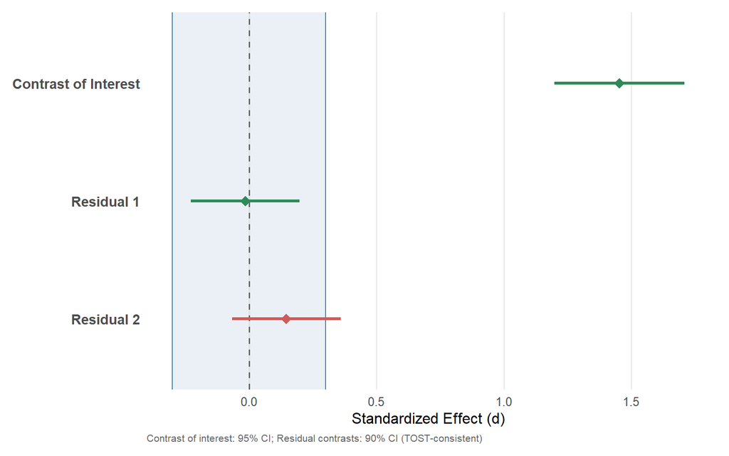

```r
p_forest <- contrast_analysis(
  data_between, "score", "group",
  hypothesis = c(A = 0, B = 1, C = 2, D = 3),
  delta      = 0.3,
  graph1.only = TRUE
)
p_forest
```

### 8.1.1 How to Read It

- **Contrast of interest** (top row): The 95% CI for *d*. Colored **green** if the CI excludes zero (significant), **red** if it includes zero (not significant).
- **Residual contrasts** (lower rows): The 90% CI for *d* (TOST-consistent). Colored **green** if the entire CI falls within the equivalence bounds (the shaded blue region), **red** if any part of the CI extends beyond the bounds.
- **Shaded region**: The equivalence bounds (±delta). If you specified different deltas per residual, the shaded region spans the largest delta, and each residual is colored against its own individual bound.
- **Dashed vertical line**: Zero.

### 8.1.2 When to Use `graph1.only`

If you just want the ggplot object (e.g., to customize or save it), use `graph1.only = TRUE`. This returns the plot without printing the full text output:

```r
p <- contrast_analysis(..., graph1.only = TRUE)
ggsave("my_forest_plot.png", p, width = 7, height = 4, dpi = 300)
```

## 8.2 Variance Decomposition Plot (`graph2`)

This bar chart shows what percentage of the model variance is accounted for by each contrast:

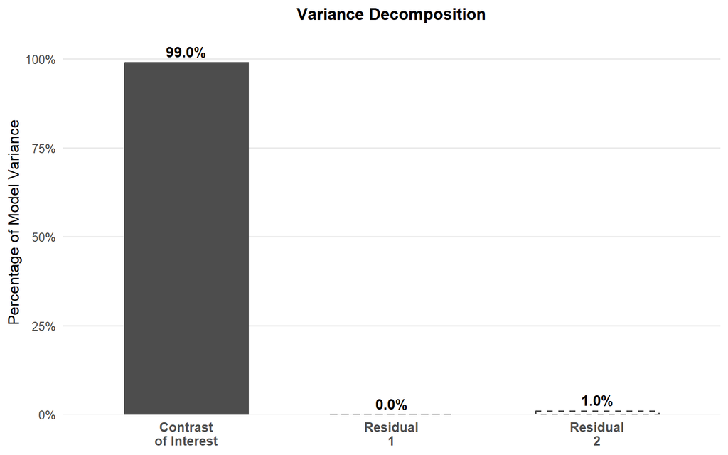

```r
p_var <- contrast_analysis(
  data_between, "score", "group",
  hypothesis = c(A = 0, B = 1, C = 2, D = 3),
  delta      = 0.3,
  graph2.only = TRUE
)
p_var
```

The contrast of interest bar is filled (dark grey); residual bars are outlined with dashed lines. In a well-fitting model, the contrast of interest should dominate (95%+).

## 8.3 Showing Both Plots Together

Set `graph1 = TRUE` and `graph2 = TRUE` to print both alongside the full text output:

```r
result <- contrast_analysis(
  data_between, "score", "group",
  hypothesis = c(A = 0, B = 1, C = 2, D = 3),
  delta      = 0.3,
  graph1     = TRUE,
  graph2     = TRUE
)
```

# 9 Working with the Return Object

The function prints its output automatically, but it also **invisibly returns** a list containing all computed values. You can capture this for further use:

```r
result <- contrast_analysis(
  data_between, "score", "group",
  hypothesis = c(A = 0, B = 1, C = 2, D = 3),
  delta      = 0.3,
  graph1     = FALSE
)
```

```
##
## =================================================================
##       CONTRAST ANALYSIS WITH EQUIVALENCE TESTING
## =================================================================
##
## Design:  between-subjects
## Groups:  A, B, C, D (k = 4)
## N:       240
## Alpha:   0.05
## Orthogonal contrasts: Yes
## Effect size metric: d = b / sigma (b = contrast coefficient, sigma = sqrt(MSE))
##
## Hypothesized pattern: A < B < C < D
##
## ----- Contrast Weights -----
##                 InterestResidual 1Residual 2
##   A              -0.6708   -0.4236   -0.3472
##   B              -0.2236    0.3060    0.7787
##   C               0.2236    0.6588   -0.5157
##   D               0.6708   -0.5412    0.0843
##
##   Note: Residual contrasts are one possible orthonormal basis for the
##   subspace orthogonal to the predicted pattern. Individual residual
##   vectors are not uniquely defined, but their joint test is invariant:
##   if any systematic deviation from the predicted pattern exists, at
##   least one residual will detect it.
##
## ----- Contrast of Interest (NHST) -----
##   b = 4.225, SE = 0.375, t(236) = 11.254, p < .001 [SIGNIFICANT]
##   d = 1.453, 95% CI [1.198, 1.707]
##
## ----- Residual Contrasts (TOST Equivalence Tests) -----
##   Equivalence bounds (standardized): +/-0.300, +/-0.300
##
##   Residual 1:
##     Weights: A: -0.424, B: +0.306, C: +0.659, D: -0.541
##     NHST: b = -0.043, SE = 0.375, t(236) = -0.113, p = 0.910
##     TOST: d = -0.015, 90% CI [-0.228, 0.199]
##           p1 = 0.014, p2 = 0.008, p_TOST = 0.014 [EQUIVALENT (within bounds)]
##
```

[output cut: 9 more lines]

```
##   Residual 2:           1.0%
##
## =================================================================
##   CONCLUSION: PARTIALLY SUPPORTED
## =================================================================
##   The data partially support the hypothesized pattern. The
##   contrast of interest is statistically significant, but not all
##   residual contrasts could be declared equivalent to zero. The
##   hypothesized pattern does not fully account for the
##   between-condition differences.
##
## ----- APA-Formatted Results -----
## Contrast of interest: b = 4.23, SE = 0.38, t(236) = 11.25, p < .001, d = 1.45, 95% CI [1.20, 1.71].
## Residual contrast 1 (TOST): b = -0.04, SE = 0.38, d = -0.01, 90% CI [-0.23, 0.20], equivalence bounds = +/-0.30, t1(236) = 2.21, p1 = .014, t2(236) = -2.44, p2 = .008, p_TOST = .014 (equivalent to zero).
## Residual contrast 2 (TOST): b = 0.43, SE = 0.38, d = 0.15, 90% CI [-0.07, 0.36], equivalence bounds = +/-0.30, t1(236) = 3.46, p1 < .001, t2(236) = -1.19, p2 = .118, p_TOST = .118 (not equivalent to zero).
```

Here are some useful things you can extract:

```r
# The qualitative conclusion
result$conclusion
```

```
## [1] "PARTIALLY SUPPORTED"
```

```r
# The contrast of interest effect size and p-value
result$interest$d
```

```
## [1] 1.45283
```

```r
result$interest$p
```

```
## [1] 8.417937e-24
```

```r
# Residual 1's TOST p-value
result$residuals[[1]]$p_tost
```

```
## [1] 0.01401752
```

```r
# Whether each residual was declared equivalent
result$residuals_equiv
```

```
## [1]  TRUE FALSE
```

```r
# Variance decomposition percentages
result$variance$pct_interest
```

```
## [1] 98.98481
```

```r
result$variance$pct_residuals
```

```
## [1] 0.01004323 1.00514652
```

```r
# The APA-formatted text (copy-paste ready)
cat(result$apa)
```

```
## Contrast of interest: b = 4.23, SE = 0.38, t(236) = 11.25, p < .001, d = 1.45, 95% CI [1.20, 1.71].
## Residual contrast 1 (TOST): b = -0.04, SE = 0.38, d = -0.01, 90% CI [-0.23, 0.20], equivalence bounds = +/-0.30, t1(236) = 2.21, p1 = .014, t2(236) = -2.44, p2 = .008, p_TOST = .014 (equivalent to zero).
## Residual contrast 2 (TOST): b = 0.43, SE = 0.38, d = 0.15, 90% CI [-0.07, 0.36], equivalence bounds = +/-0.30, t1(236) = 3.46, p1 < .001, t2(236) = -1.19, p2 = .118, p_TOST = .118 (not equivalent to zero).
```

The full list of returned elements is documented in the table below:

| Element | Description |
| --- | --- |
| interest | List with b, se, t, df, p, d, se_d, ci_b, ci_d for the contrast of interest. |
| residuals | List of lists, one per residual, each with NHST + TOST results. |
| model | The fitted lm object (between-subjects) or NULL (within-subjects). |
| design | ‘between’ or ‘within’. |
| hypothesis | The hypothesis vector you supplied. |
| hyp_levels | Character vector of condition names (in hypothesis order). |
| w_interest | Normalized contrast weights for the interest contrast. |
| residual_basis | Matrix of residual contrast weights (k x (k-2)). |
| n_residuals | Number of residual contrasts (k - 2). |
| delta_vec | Numeric vector of equivalence bounds in d units (after conversion if share_signal). |
| delta_type | ‘dz’ or ‘share_signal’. |
| delta_share_pct | The share percentages you specified (NA if delta_type = ‘dz’). |
| d_interest_min | The reference d for the interest contrast (NA if delta_type = ‘dz’). |
| alpha | The alpha level used. |
| alpha_tost | The alpha level used for TOST (may differ if Bonferroni applied). |
| is_orthogonal | TRUE if all contrasts are orthogonal. |
| bonferroni_applied | TRUE if Bonferroni correction was applied to TOST alpha. |
| contrast_matrix | Full contrast matrix (interest + residuals). |
| k | Number of groups/conditions. |
| conclusion | ‘SUPPORTED’, ‘PARTIALLY SUPPORTED’, or ‘NOT SUPPORTED’. |
| conclusion_text | A plain-English sentence summarizing the conclusion. |
| residuals_equiv | Logical vector: TRUE for each residual declared equivalent. |
| apa | APA-formatted results string. |
| variance | List with ss_interest, ss_residuals, ss_model, pct_interest, pct_residuals. |
| plot_forest | ggplot object for the forest plot (NULL if graph1 = FALSE). |
| plot_variance | ggplot object for the variance plot (NULL if graph2 = FALSE). |

# 10 Confirming Your Setup Before Running (`confirm = TRUE`)

If you want to verify that the function has interpreted your hypothesis correctly before it runs the analysis, use `confirm = TRUE`:

```r
result <- contrast_analysis(
  data_between, "score", "group",
  hypothesis = c(A = 0, B = 1, C = 2, D = 3),
  delta      = 0.3,
  confirm    = TRUE
)
```

This will print:

- The hypothesized pattern in plain language (e.g., `A < B < C < D`).
- The normalized contrast weights.
- All residual contrast weights.
- The orthogonality status.
- The equivalence bounds.

It then pauses and waits for you to press Enter to continue (or Esc to abort). This is especially helpful when you’re learning the function or when your hypothesis has equality constraints.

# 11 Putting It All Together: A Complete Worked Example

Let’s walk through a realistic scenario from start to finish.

**Research question:** We exposed participants to 0, 1, 3, or 5 hours of violent video game play and measured subsequent aggression. We predict a linear dose–response relationship. We consider residual deviations negligible if they account for less than 5% of the model variance, and our SESOI for the main linear trend is *d* = 0.50.

```
##
## =================================================================
##       CONTRAST ANALYSIS WITH EQUIVALENCE TESTING
## =================================================================
##
## Design:  between-subjects
## Groups:  0hr, 1hr, 3hr, 5hr (k = 4)
## N:       300
## Alpha:   0.05
## Orthogonal contrasts: Yes
## Effect size metric: d = b / sigma (b = contrast coefficient, sigma = sqrt(MSE))
##
## Hypothesized pattern: 0hr < 1hr < 3hr < 5hr
##
## ----- Contrast Weights -----
##                 InterestResidual 1Residual 2
##   0hr            -0.5859   -0.4703   -0.4308
##   1hr            -0.3255    0.2338    0.7677
##   3hr             0.1953    0.7083   -0.4585
##   5hr             0.7160   -0.4717    0.1216
##
##   Note: Residual contrasts are one possible orthonormal basis for the
##   subspace orthogonal to the predicted pattern. Individual residual
##   vectors are not uniquely defined, but their joint test is invariant:
##   if any systematic deviation from the predicted pattern exists, at
##   least one residual will detect it.
##
## ----- Contrast of Interest (NHST) -----
##   b = 3.654, SE = 0.274, t(296) = 13.357, p < .001 [SIGNIFICANT]
##   d = 1.542, 95% CI [1.315, 1.770]
##
## ----- Residual Contrasts (TOST Equivalence Tests) -----
##   Delta type: share_signal (% of model variance)
##   Reference d_interest_min: 0.5
##   Equivalence bounds (converted to d-scale):
##     Residual 1: max share = 5.0% => d bound = +/-0.1147
##     Residual 2: max share = 5.0% => d bound = +/-0.1147
##
##   Residual 1:
##     Weights: 0hr: -0.470, 1hr: +0.234, 3hr: +0.708, 5hr: -0.472
```

[output cut: 23 more lines]

```
##   implicitly (interest must be significant for SUPPORTED).
##
## =================================================================
##   CONCLUSION: PARTIALLY SUPPORTED
## =================================================================
##   The data partially support the hypothesized pattern. The
##   contrast of interest is statistically significant, but not all
##   residual contrasts could be declared equivalent to zero. The
##   hypothesized pattern does not fully account for the
##   between-condition differences.
##
## ----- APA-Formatted Results -----
## Contrast of interest: b = 3.65, SE = 0.27, t(296) = 13.36, p < .001, d = 1.54, 95% CI [1.32, 1.77].
## Residual contrast 1 (TOST): b = 0.03, SE = 0.27, d = 0.01, 90% CI [-0.18, 0.20], equivalence bounds = +/-0.115 (from 5.0% share, d_int_min = 0.50), t1(296) = 1.10, p1 = .137, t2(296) = -0.89, p2 = .187, p_TOST = .187 (not equivalent to zero).
## Residual contrast 2 (TOST): b = -0.02, SE = 0.27, d = -0.01, 90% CI [-0.20, 0.18], equivalence bounds = +/-0.115 (from 5.0% share, d_int_min = 0.50), t1(296) = 0.92, p1 = .180, t2(296) = -1.07, p2 = .143, p_TOST = .180 (not equivalent to zero).
```

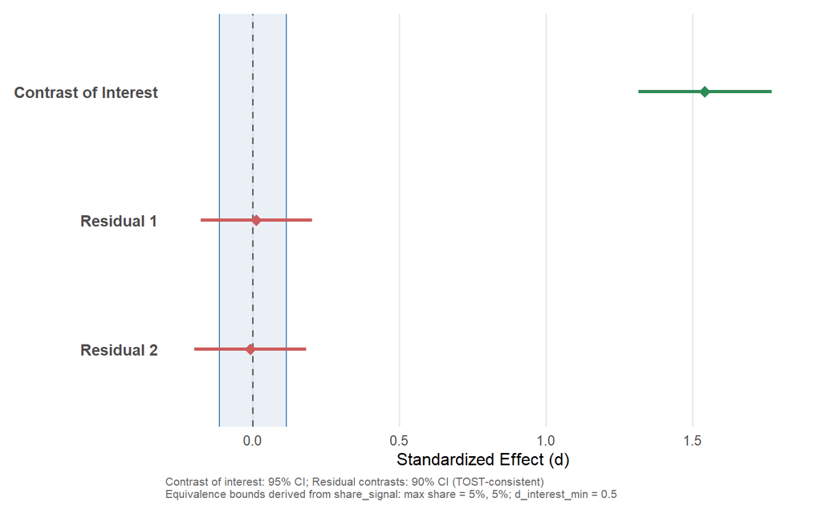

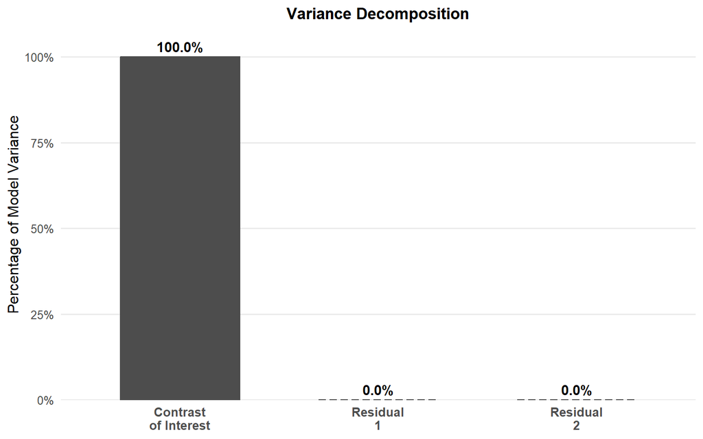

```r
set.seed(123)

# Simulate data
aggression_data <- data.frame(
  hours = rep(c("0hr", "1hr", "3hr", "5hr"), each = 75),
  aggression = c(
    rnorm(75, mean = 3.0, sd = 2.5),
    rnorm(75, mean = 4.2, sd = 2.5),
    rnorm(75, mean = 5.8, sd = 2.5),
    rnorm(75, mean = 7.5, sd = 2.5)
  )
)

# Run contrast analysis
result_full <- contrast_analysis(
  data       = aggression_data,
  dv         = "aggression",
  conditions = "hours",
  hypothesis = c(`0hr` = 0, `1hr` = 1, `3hr` = 3, `5hr` = 5),
  delta      = 5,
  delta_type = "share_signal",
  d_interest_min = 0.50,
  graph1     = TRUE,
  graph2     = TRUE
)
```

**Note the hypothesis values.** We didn’t use c(0, 1, 2, 3) — we used c(0, 1, 3, 5) to match the actual hours of exposure. This means we’re predicting that aggression scales with actual dose, not ordinal position. The spacing matters: we expect the jump from 1hr to 3hr to be twice as large as the jump from 0hr to 1hr.

### 11.0.1 Interpreting the APA Output

The `result_full$apa` field gives you copy-paste-ready text for your results section:

```r
cat(result_full$apa)
```

```
## Contrast of interest: b = 3.65, SE = 0.27, t(296) = 13.36, p < .001, d = 1.54, 95% CI [1.32, 1.77].
## Residual contrast 1 (TOST): b = 0.03, SE = 0.27, d = 0.01, 90% CI [-0.18, 0.20], equivalence bounds = +/-0.115 (from 5.0% share, d_int_min = 0.50), t1(296) = 1.10, p1 = .137, t2(296) = -0.89, p2 = .187, p_TOST = .187 (not equivalent to zero).
## Residual contrast 2 (TOST): b = -0.02, SE = 0.27, d = -0.01, 90% CI [-0.20, 0.18], equivalence bounds = +/-0.115 (from 5.0% share, d_int_min = 0.50), t1(296) = 0.92, p1 = .180, t2(296) = -1.07, p2 = .143, p_TOST = .180 (not equivalent to zero).
```

# 12 Quick Reference: All Function Arguments

| Argument | Default | Description |
| --- | --- | --- |
| data | (required) | Data frame containing the data. |
| dv | (required) | Name of the DV column (string). Set NULL for within-subjects. |
| conditions | (required) | Name of the grouping variable column (string). Set NULL for within-subjects. |
| hypothesis | (required) | Named numeric vector: names = condition labels, values = predicted pattern. |
| design | “between” | ‘between’ or ‘within’. |
| id | NULL | Name of the participant ID column (required for within-subjects). |
| delta | 0.3 | Equivalence bound(s). Scalar (same for all residuals) or vector (one per residual). Units depend on delta_type. |
| delta_type | “dz” | ‘dz’ (bound in d units) or ‘share_signal’ (bound in % of model variance). |
| d_interest_min | NULL | SESOI for the contrast of interest in d units. Required when delta_type = ‘share_signal’. |
| alpha | 0.05 | Significance level. |
| confirm | FALSE | If TRUE, display the setup and pause for confirmation before running. |
| bonferroni | TRUE | If TRUE and contrasts are non-orthogonal, apply Bonferroni to TOST alpha. (Auto-generated contrasts are always orthogonal, so this rarely activates.) |
| graph1 | TRUE | If TRUE, display the forest plot. |
| graph1.only | FALSE | If TRUE, return ONLY the forest plot (as a ggplot object), skip all other output. |
| graph2 | FALSE | If TRUE, display the variance decomposition plot. |
| graph2.only | FALSE | If TRUE, return ONLY the variance plot (as a ggplot object), skip all other output. |

# 13 Common Questions

**Q: Do I need at least 3 groups?** Yes. With only 2 groups, there is no residual subspace — a standard *t*-test is sufficient. The function will stop with an error if *k* < 3.

**Q: Does the order of names in the hypothesis vector matter?** No. The function matches names to factor levels, not positions. `c(B = 1, A = 0, C = 2)` is identical to `c(A = 0, B = 1, C = 2)`.

**Q: What if my groups have unequal sample sizes?** The function handles unbalanced designs. The contrast weights and TOST tests are computed from the fitted linear model, which accommodates unequal *n*. However, the variance decomposition percentages and the `share_signal` conversion are most cleanly interpretable with balanced designs.

**Q: Can I use this with more than 6 groups?** Yes. The function works for any *k* ≥ 3. With *k* groups you’ll get *k* − 2 residual contrasts.

**Q: What are the residual contrasts, exactly?** They are an orthonormal basis for the subspace orthogonal to both the intercept and your contrast of interest. The function computes them automatically using `MASS::Null()`. The specific basis vectors are arbitrary (any rotation within this subspace would work), but their joint behavior is invariant — if any deviation from your pattern exists, at least one residual will detect it.

**Q: Is the alpha correction handled automatically?** Yes. The function uses the Intersection-Union Test (IUT) principle: because the contrasts are orthogonal, the overall Type I error rate is at most alpha without any correction. Within each TOST, each one-sided test is conducted at alpha (not alpha/2), following Lakens (2017).